# Task 2: Painting Similarity Search

## GSoC 2025 — ArtExtract: Neural Networks for Artworks

This notebook implements a painting similarity search system using:

- **ResNet-50** pretrained backbone for feature extraction
- **Cosine similarity** over L2-normalized embeddings
- **National Gallery of Art Open Data** dataset
- **Precision@k, Recall@k, mAP** evaluation metrics

## 1. Setup & Dependencies

```python
# Mount Google Drive for persistent storage
from google.colab import drive
drive.mount('/content/drive')

# Create results directory
import os
RESULTS_DIR = '/content/drive/MyDrive/Similarity_Results'
os.makedirs(RESULTS_DIR, exist_ok=True)
print(f'Results will be saved to: {RESULTS_DIR}')
```

```
Results will be saved to: /content/drive/MyDrive/Similarity_Results
```

```python
!pip install -q matplotlib seaborn tqdm pandas Pillow
```

## 2. Download the NGA Open Data Dataset

We use the [National Gallery of Art Open Data](https://github.com/NationalGalleryOfArt/opendata) repository. This contains metadata CSV files. For images, we'll download a sample from their IIIF API.

```python
# Clone the NGA Open Data repo for metadata
!git clone --depth 1 https://github.com/NationalGalleryOfArt/opendata.git /content/nga_opendata
!ls /content/nga_opendata/data/
```

```
Cloning into '/content/nga_opendata'...
remote: Enumerating objects: 53, done.
remote: Counting objects: 100% (53/53), done.
remote: Compressing objects: 100% (37/37), done.
remote: Total 53 (delta 15), reused 30 (delta 15), pack-reused 0 (from 0)
Receiving objects: 100% (53/53), 44.43 MiB | 7.22 MiB/s, done.
Resolving deltas: 100% (15/15), done.
Updating files: 100% (46/46), done.
alternative_identifiers.csv    objects.csv
constituents_altnames.csv      objects_dimensions.csv
constituents.csv	       objects_historical_data.csv
constituents_text_entries.csv  objects_terms.csv
locations.csv		       objects_text_entries.csv
media_items.csv		       preferred_locations.csv
media_relationships.csv        preferred_locations_tms_locations.csv
object_associations.csv        published_images.csv
objects_constituents.csv
```

```python
import pandas as pd

# Load the objects metadata
objects_df = pd.read_csv('/content/nga_opendata/data/objects.csv', low_memory=False)
print(f'Total objects in NGA: {len(objects_df)}')
print(f'Columns: {list(objects_df.columns)}')
objects_df.head()
```

```
Total objects in NGA: 144192
Columns: ['objectid', 'uuid', 'accessioned', 'accessionnum', 'locationid', 'title', 'displaydate', 'beginyear', 'endyear', 'visualbrowsertimespan', 'medium', 'dimensions', 'inscription', 'markings', 'attributioninverted', 'attribution', 'provenancetext', 'creditline', 'classification', 'subclassific…
```

|  | objectid | uuid | accessioned | accessionnum | locationid | title | displaydate | beginyear | endyear | visualbrowsertimespan | ... | parentid | isvirtual | departmentabbr | portfolio | series | volume | watermarks | lastdetectedmodification | wikidataid | customprinturl |
| --- | --- | --- | --- | --- | --- | --- | --- | --- | --- | --- | --- | --- | --- | --- | --- | --- | --- | --- | --- | --- | --- |
| 0 | 0 | b5dc500c-be86-4b05-93fa-59a25d8775fb | 1 | 1937.1.2.c | NaN | Saint James Major | c. 1310 | 1310.0 | 1310.0 | 1300 to 1400 | ... | 34.0 | 0 | CIS-R | NaN | NaN | NaN | NaN | 2023-05-09 17:01:03.48-04 | Q20172973 | NaN |
| 1 | 1 | 59e0e07c-208e-4d24-a3d3-f4a56d20d6d3 | 1 | 1937.1.3 | NaN | Saint Paul and a Group of Worshippers | 1333 | 1333.0 | 1333.0 | 1300 to 1400 | ... | NaN | 0 | CIS-R | NaN | NaN | NaN | NaN | 2024-02-12 16:33:23.167-05 | Q20173083 | NaN |
| 2 | 2 | 95cfbfd3-5947-4834-b1cf-bf92ee1a7340 | 1 | 1937.1.4.a | 8198.0 | Saint Andrew and Saint Benedict with the Archa... | shortly before 1387 | 1387.0 | 1387.0 | 1300 to 1400 | ... | 206122.0 | 0 | CIS-R | NaN | NaN | NaN | NaN | 2024-03-08 14:32:09.57-05 | Q20173290 | NaN |
| 3 | 3 | 3277a6d0-d92e-4684-9d86-2be2cbe3c5f2 | 1 | 1937.1.4.b | 8198.0 | Madonna and Child Enthroned with Twelve Angels... | shortly before 1387 | 1387.0 | 1387.0 | 1300 to 1400 | ... | 206122.0 | 0 | CIS-R | NaN | NaN | NaN | NaN | 2024-03-08 14:32:09.57-05 | Q20173280 | NaN |
| 4 | 4 | 63225dec-d421-4ece-9f2a-335dd2dfeea1 | 1 | 1937.1.4.c | 8198.0 | Saint Bernard and Saint Catherine of Alexandri... | shortly before 1387 | 1387.0 | 1387.0 | 1300 to 1400 | ... | 206122.0 | 0 | CIS-R | NaN | NaN | NaN | NaN | 2024-03-08 14:32:09.57-05 | Q20173299 | NaN |

5 rows × 31 columns

```python
print(objects_df.columns.tolist())
print(objects_df.head(2))
```

```
['objectid', 'uuid', 'accessioned', 'accessionnum', 'locationid', 'title', 'displaydate', 'beginyear', 'endyear', 'visualbrowsertimespan', 'medium', 'dimensions', 'inscription', 'markings', 'attributioninverted', 'attribution', 'provenancetext', 'creditline', 'classification', 'subclassification', '…
   objectid                                  uuid  accessioned accessionnum  \
0         0  b5dc500c-be86-4b05-93fa-59a25d8775fb            1   1937.1.2.c
1         1  59e0e07c-208e-4d24-a3d3-f4a56d20d6d3            1     1937.1.3

   locationid                                  title displaydate  beginyear  \
0         NaN                      Saint James Major     c. 1310     1310.0
1         NaN  Saint Paul and a Group of Worshippers        1333     1333.0

   endyear visualbrowsertimespan  ... parentid isvirtual departmentabbr  \
0   1310.0          1300 to 1400  ...     34.0         0          CIS-R
1   1333.0          1300 to 1400  ...      NaN         0          CIS-R

  portfolio series volume watermarks    lastdetectedmodification wikidataid  \
0       NaN    NaN    NaN        NaN   2023-05-09 17:01:03.48-04  Q20172973
1       NaN    NaN    NaN        NaN  2024-02-12 16:33:23.167-05  Q20173083

  customprinturl
0            NaN
1            NaN

[2 rows x 31 columns]
```

```python
# The NGA dataset splits info across multiple CSVs — let's check what's available
import os
data_dir = '/content/nga_opendata/data'
print("Available data files:")
for f in sorted(os.listdir(data_dir)):
    print(f"  {f}")

# Load published images (has IIIF URLs)
images_df = pd.read_csv(os.path.join(data_dir, 'published_images.csv'), low_memory=False)
print(f"\nImages: {len(images_df)} rows")
print(f"Image columns: {images_df.columns.tolist()}")

# Load constituents (artists)
constituents_df = pd.read_csv(os.path.join(data_dir, 'constituents.csv'), low_memory=False)
print(f"\nConstituents: {len(constituents_df)} rows")
print(f"Constituent columns: {constituents_df.columns.tolist()}")

# Load object-constituent links
obj_const_df = pd.read_csv(os.path.join(data_dir, 'objects_constituents.csv'), low_memory=False)
print(f"\nObject-Constituent links: {len(obj_const_df)} rows")

# Find the IIIF URL column in images
url_col = None
for col in images_df.columns:
    if 'iiif' in col.lower() or 'url' in col.lower() or 'thumb' in col.lower():
        non_null = images_df[col].notna().sum()
        print(f"\n  Potential URL column: '{col}' ({non_null} non-null)")
        sample = images_df[col].dropna().head(2).tolist()
        print(f"    Sample: {sample}")
        if url_col is None and non_null > 100:
            url_col = col

print(f"\nUsing URL column: '{url_col}'")
```

```
Available data files:
  alternative_identifiers.csv
  constituents.csv
  constituents_altnames.csv
  constituents_text_entries.csv
  locations.csv
  media_items.csv
  media_relationships.csv
  object_associations.csv
  objects.csv
  objects_constituents.csv
  objects_dimensions.csv
  objects_historical_data.csv
  objects_terms.csv
  objects_text_entries.csv
  preferred_locations.csv
  preferred_locations_tms_locations.csv
  published_images.csv

Images: 130938 rows
Image columns: ['uuid', 'iiifurl', 'iiifthumburl', 'viewtype', 'sequence', 'width', 'height', 'maxpixels', 'openaccess', 'created', 'modified', 'depictstmsobjectid', 'assistivetext']

Constituents: 27771 rows
Constituent columns: ['constituentid', 'uuid', 'ulanid', 'preferreddisplayname', 'forwarddisplayname', 'lastname', 'displaydate', 'artistofngaobject', 'beginyear', 'endyear', 'visualbrowsertimespan', 'nationality', 'visualbrowsernationality', 'constituenttype', 'wikidataid']

Object-Constituent links: 839062 rows

  Potential URL column: 'iiifurl' (130938 non-null)
    Sample: ['https://api.nga.gov/iiif/00007f61-4922-417b-8f27-893ea328206c', 'https://api.nga.gov/iiif/0000bd8c-39de-4453-b55d-5e28a9beed38']

  Potential URL column: 'iiifthumburl' (130938 non-null)
    Sample: ['https://api.nga.gov/iiif/00007f61-4922-417b-8f27-893ea328206c/full/!200,200/0/default.jpg', 'https://api.nga.gov/iiif/0000bd8c-39de-4453-b55d-5e28a9beed38/full/!200,200/0/default.jpg']

Using URL column: 'iiifurl'
```

```python
# Debug: check all columns in images_df and find the link to objects
print("ALL images_df columns:")
print(images_df.columns.tolist())
print("\nSample row:")
print(images_df.iloc[0])

print("\n\n--- Checking for objectid-like columns in images ---")
for col in images_df.columns:
    if 'object' in col.lower() or 'depict' in col.lower() or 'parent' in col.lower():
        print(f"  '{col}': {images_df[col].head(3).tolist()}")

# Also check if UUIDs match at all
print("\n--- UUID comparison ---")
print(f"Images uuid sample: {images_df['uuid'].head(3).tolist()}")
print(f"Objects uuid sample: {objects_df['uuid'].head(3).tolist()}")

# Check if any image uuid exists in objects
overlap = set(images_df['uuid']) & set(objects_df['uuid'])
print(f"\nUUID overlap between images and objects: {len(overlap)}")

# Check media_relationships for the link
media_rel_path = '/content/nga_opendata/data/media_relationships.csv'
if os.path.exists(media_rel_path):
    media_rel = pd.read_csv(media_rel_path, low_memory=False)
    print(f"\nmedia_relationships columns: {media_rel.columns.tolist()}")
    print(media_rel.head(3))

media_items_path = '/content/nga_opendata/data/media_items.csv'
if os.path.exists(media_items_path):
    media_items = pd.read_csv(media_items_path, low_memory=False)
    print(f"\nmedia_items columns: {media_items.columns.tolist()}")
    print(media_items.head(3))
```

```
ALL images_df columns:
['uuid', 'iiifurl', 'iiifthumburl', 'viewtype', 'sequence', 'width', 'height', 'maxpixels', 'openaccess', 'created', 'modified', 'depictstmsobjectid', 'assistivetext']

Sample row:
uuid                               00007f61-4922-417b-8f27-893ea328206c
iiifurl               https://api.nga.gov/iiif/00007f61-4922-417b-8f...
iiifthumburl          https://api.nga.gov/iiif/00007f61-4922-417b-8f...
viewtype                                                        primary
sequence                                                              0
width                                                              3365
height                                                             4332
maxpixels                                                           NaN
openaccess                                                            1
created                                          2013-07-05 15:41:08-04
modified                                         2025-09-22 14:10:53-04
depictstmsobjectid                                                17387
assistivetext                                                       NaN
Name: 0, dtype: object


--- Checking for objectid-like columns in images ---
  'depictstmsobjectid': [17387, 19245, 23830]

--- UUID comparison ---
Images uuid sample: ['00007f61-4922-417b-8f27-893ea328206c', '0000bd8c-39de-4453-b55d-5e28a9beed38', '0001668a-dd1c-48e8-9267-b6d1697d43c8']
Objects uuid sample: ['b5dc500c-be86-4b05-93fa-59a25d8775fb', '59e0e07c-208e-4d24-a3d3-f4a56d20d6d3', '95cfbfd3-5947-4834-b1cf-bf92ee1a7340']

UUID overlap between images and objects: 0

media_relationships columns: ['mediaid', 'relatedid', 'relatedentity']
    mediaid  relatedid             relatedentity
0       111       1926  nga:art:tms:constituents
1  78025867        229  nga:art:tms:constituents
2  78150710       1939  nga:art:tms:constituents

media_items columns: ['mediaid', 'mediatype', 'title', 'description', 'duration', 'language', 'thumbnailurl', 'playurl', 'downloadurl', 'keywords', 'tags', 'imageurl', 'presentationdate', 'releasedate', 'lastmodified']
    mediaid mediatype                                              title  \
0       111     audio  John Wilmerding Symposium on American Art and ...
1  77997857     audio  National Gallery of Art String Quartet, Wind Q...
2  78008083     audio         National Gallery of Art New Music Ensemble
```

[output cut: 25 more lines]

```

                                                tags  \
0  ngaweb:constituents/1/9/2/6/Constituent_1926,n...
1  ngaweb:audio-video/audio,ngaweb:audio-video/music
2  ngaweb:audio-video/audio,ngaweb:audio-video/music

                                            imageurl        presentationdate  \
0  https://www.nga.gov/content/dam/ngaweb/audio-v...  2021-09-22 00:00:00-04
1  https://www.nga.gov/content/dam/ngaweb/audio-v...  2012-03-27 00:00:00-04
2  https://www.nga.gov/content/dam/ngaweb/audio-v...  2012-02-21 00:00:00-05

              releasedate            lastmodified
0  2021-09-22 00:00:00-04  2022-07-05 14:37:41-04
1  2012-03-27 00:00:00-04  2014-05-30 14:37:16-04
2  2012-02-21 00:00:00-05  2014-04-25 11:43:15-04
```

```python
import requests
from PIL import Image
from io import BytesIO
from tqdm import tqdm
import time

# Step 1: Join images → objects using depictstmsobjectid → objectid
paintings_df = images_df.merge(
    objects_df[['objectid', 'uuid', 'title']],
    left_on='depictstmsobjectid', right_on='objectid', how='inner',
    suffixes=('_img', '_obj')
)
print(f"Images with object info: {len(paintings_df)}")

# Step 2: Join with constituents to get artist names
obj_artists = obj_const_df.merge(
    constituents_df[['constituentid', 'preferreddisplayname']],
    on='constituentid', how='inner'
)
paintings_df = paintings_df.merge(
    obj_artists[['objectid', 'preferreddisplayname']].drop_duplicates(subset='objectid'),
    on='objectid', how='left'
)
paintings_df.rename(columns={'preferreddisplayname': 'artist'}, inplace=True)
paintings_df['artist'] = paintings_df['artist'].fillna('Unknown')

# Keep only primary views, drop duplicates
paintings_df = paintings_df[paintings_df['viewtype'] == 'primary'].drop_duplicates(subset='objectid')

print(f"Paintings with artist info: {len(paintings_df)}")
print(f"\nTop artists:")
print(paintings_df['artist'].value_counts().head(15))

# Step 3: Keep artists with 3+ paintings for evaluation
MAX_IMAGES = 500
artist_counts = paintings_df['artist'].value_counts()
valid_artists = artist_counts[artist_counts >= 3].index
eval_paintings = paintings_df[paintings_df['artist'].isin(valid_artists)].copy()

if len(eval_paintings) > MAX_IMAGES:
    eval_paintings = eval_paintings.sample(n=MAX_IMAGES, random_state=42)

print(f'\nSelected {len(eval_paintings)} paintings from {eval_paintings["artist"].nunique()} artists')

# Step 4: Download images
IMAGE_DIR = '/content/nga_images'
os.makedirs(IMAGE_DIR, exist_ok=True)

downloaded = []
failed = 0

for idx, row in tqdm(eval_paintings.iterrows(), total=len(eval_paintings), desc='Downloading images'):
    thumb_url = row['iiifthumburl']
    obj_id = row['objectid']
    save_path = os.path.join(IMAGE_DIR, f'{obj_id}.jpg')

    if os.path.exists(save_path):
        downloaded.append({'objectid': int(obj_id), 'path': save_path, 'title': str(row.get('title', '')), 'artist': str(row.get('artist', 'Unknown'))})
        continue

    try:
        iiif_url = str(thumb_url).replace('/full/!200,200/', '/full/!400,400/')
        resp = requests.get(iiif_url, timeout=10)
        if resp.status_code == 200:
            img = Image.open(BytesIO(resp.content)).convert('RGB')
            img.save(save_path, 'JPEG', quality=90)
            downloaded.append({'objectid': int(obj_id), 'path': save_path, 'title': str(row.get('title', '')), 'artist': str(row.get('artist', 'Unknown'))})
        else:
            failed += 1
    except:
        failed += 1

    time.sleep(0.05)

print(f'\nDownloaded: {len(downloaded)} | Failed: {failed}')
```

```
Images with object info: 127109
Paintings with artist info: 118072

Top artists:
artist
National Gallery of Art    117100
Anonymous                     968
Komor, Mathias, Mr.             2
Baldung, Hans                   1
Patrons' Permanent Fund         1
Name: count, dtype: int64

Selected 500 paintings from 2 artists
```

```
Downloaded: 498 | Failed: 2
```

```python
  # Save metadata for downloaded paintings
  import json

  metadata_path = os.path.join(IMAGE_DIR, 'metadata.json')
  with open(metadata_path, 'w') as f:
      json.dump(downloaded, f, indent=2, default=str)
  print(f'Saved metadata for {len(downloaded)} paintings')
```

```
Saved metadata for 498 paintings
```

## 3. Upload Similarity Code

Upload the Python modules from your local machine.

```python
# DIDN'T RAN IT
# Option A: Upload files manually
# from google.colab import files
# uploaded = files.upload()  # Upload feature_extractor.py, similarity_search.py, evaluate_similarity.py

# Option B: Copy from Drive (if you've uploaded to Drive already)
# !cp /content/drive/MyDrive/Similarity/*.py /content/

# Option C: Write inline (the next cells contain the code directly)
print('Code modules are ready. Proceeding...')
```

```
Code modules are ready. Proceeding...
```

## 4. Feature Extraction

Extract 2048-dimensional embeddings from all downloaded paintings using ResNet-50.

```python
import torch
import torch.nn as nn
import numpy as np
from torch.utils.data import Dataset, DataLoader
from torchvision import models, transforms
from PIL import Image
from tqdm import tqdm

device = torch.device('cuda' if torch.cuda.is_available() else 'cpu')
print(f'Using device: {device}')

# Feature extractor model
class PaintingFeatureExtractor(nn.Module):
    def __init__(self):
        super().__init__()
        resnet = models.resnet50(weights=models.ResNet50_Weights.IMAGENET1K_V2)
        self.backbone = nn.Sequential(*list(resnet.children())[:-1])
        self.embedding_dim = 2048

    def forward(self, x):
        features = self.backbone(x).squeeze(-1).squeeze(-1)
        return torch.nn.functional.normalize(features, p=2, dim=1)

# Dataset
class PaintingDataset(Dataset):
    def __init__(self, image_paths, transform):
        self.image_paths = image_paths
        self.transform = transform

    def __len__(self):
        return len(self.image_paths)

    def __getitem__(self, idx):
        try:
            img = Image.open(self.image_paths[idx]).convert('RGB')
            img = self.transform(img)
        except:
            img = torch.zeros(3, 224, 224)
        return img, idx

# Setup
transform = transforms.Compose([
    transforms.Resize((256, 256)),
    transforms.CenterCrop(224),
    transforms.ToTensor(),
    transforms.Normalize(mean=[0.485, 0.456, 0.406], std=[0.229, 0.224, 0.225])
])

# Get all image paths
image_paths = [d['path'] for d in downloaded]

dataset = PaintingDataset(image_paths, transform)
dataloader = DataLoader(dataset, batch_size=32, shuffle=False, num_workers=2)

# Extract embeddings
model = PaintingFeatureExtractor().to(device)
model.eval()

all_embeddings = []
with torch.no_grad():
    for images, indices in tqdm(dataloader, desc='Extracting features'):
        images = images.to(device)
        embeddings = model(images)
        all_embeddings.append(embeddings.cpu().numpy())

embeddings = np.concatenate(all_embeddings, axis=0)
print(f'\nExtracted embeddings: {embeddings.shape}')  # (N, 2048)

# Save
np.savez_compressed(
    os.path.join(RESULTS_DIR, 'embeddings.npz'),
    embeddings=embeddings,
    image_paths=np.array(image_paths),
    filenames=np.array([os.path.basename(p) for p in image_paths])
)
print('Embeddings saved!')
```

```
Using device: cuda
Downloading: "https://download.pytorch.org/models/resnet50-11ad3fa6.pth" to /root/.cache/torch/hub/checkpoints/resnet50-11ad3fa6.pth
```

```
Extracted embeddings: (498, 2048)
Embeddings saved!
```

## 5. Similarity Search

Find the most similar paintings for random queries using cosine similarity.

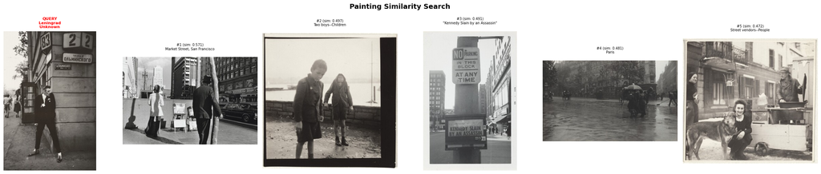

[figure not shown]

[figure not shown]

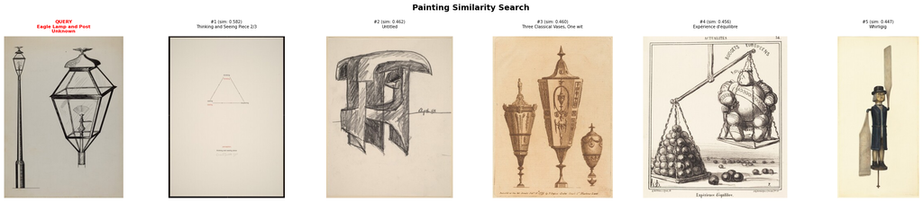

[figure not shown]

[figure not shown]

[figure not shown]

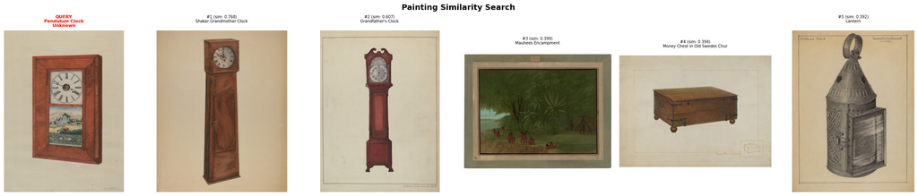

[figure not shown]

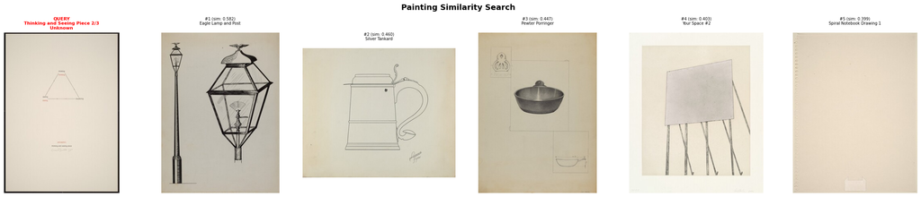

```
Saved 10 similarity visualizations to /content/drive/MyDrive/Similarity_Results
```

```python
import matplotlib.pyplot as plt

def find_similar(query_idx, embeddings, k=5):
    """Find k most similar paintings using cosine similarity."""
    similarities = embeddings @ embeddings[query_idx]
    top_indices = np.argsort(similarities)[::-1][1:k+1]  # Exclude self
    return top_indices, similarities[top_indices]

def show_similar(query_idx, embeddings, image_paths, metadata, k=5):
    """Visualize query and its most similar paintings."""
    top_indices, similarities = find_similar(query_idx, embeddings, k)

    fig, axes = plt.subplots(1, k+1, figsize=(4*(k+1), 5))

    # Query
    img = Image.open(image_paths[query_idx]).convert('RGB')
    axes[0].imshow(img)
    q_meta = metadata[query_idx]
    title = q_meta.get('title', 'Unknown')[:30]
    artist = str(q_meta.get('attribution', 'Unknown'))[:25]
    axes[0].set_title(f'QUERY\n{title}\n{artist}', fontsize=8, fontweight='bold', color='red')
    axes[0].axis('off')

    # Similar paintings
    for i, (idx, sim) in enumerate(zip(top_indices, similarities)):
        img = Image.open(image_paths[idx]).convert('RGB')
        axes[i+1].imshow(img)
        m = metadata[idx]
        t = str(m.get('title', ''))[:30]
        a = str(m.get('attribution', ''))[:25]
        axes[i+1].set_title(f'#{i+1} (sim: {sim:.3f})\n{t}\n{a}', fontsize=7)
        axes[i+1].axis('off')

    plt.suptitle('Painting Similarity Search', fontsize=14, fontweight='bold')
    plt.tight_layout()
    return fig

# Run similarity search for random queries
np.random.seed(42)
num_demos = 10
query_indices = np.random.choice(len(embeddings), num_demos, replace=False)

for i, q_idx in enumerate(query_indices):
    fig = show_similar(q_idx, embeddings, image_paths, downloaded, k=5)
    fig.savefig(os.path.join(RESULTS_DIR, f'similar_{i+1}.png'), dpi=150, bbox_inches='tight')
    plt.show()
    plt.close()

print(f'\nSaved {num_demos} similarity visualizations to {RESULTS_DIR}')
```

## 6. Evaluation Metrics

Evaluate similarity search using artist labels as ground-truth relevance. Two paintings by the same artist are considered "relevant" to each other.

```python
from collections import defaultdict

def precision_at_k(relevant, retrieved, k):
    return sum(1 for idx in retrieved[:k] if idx in relevant) / k

def recall_at_k(relevant, retrieved, k):
    if not relevant:
        return 0.0
    return sum(1 for idx in retrieved[:k] if idx in relevant) / len(relevant)

def average_precision(relevant, retrieved, max_k=50):
    retrieved = retrieved[:max_k]
    if not relevant:
        return 0.0
    precisions = []
    hits = 0
    for i, idx in enumerate(retrieved):
        if idx in relevant:
            hits += 1
            precisions.append(hits / (i + 1))
    return sum(precisions) / len(relevant) if precisions else 0.0

# Build artist groups for evaluation
labels = [str(d.get('attribution', 'unknown')) for d in downloaded]
artist_groups = defaultdict(set)
for i, label in enumerate(labels):
    if label != 'unknown' and label != 'nan':
        artist_groups[label].add(i)

# Only evaluate queries that have at least 1 other painting by the same artist
valid_queries = [i for i in range(len(labels))
                 if labels[i] in artist_groups and len(artist_groups[labels[i]]) > 1]

print(f'Valid queries (artists with 2+ paintings): {len(valid_queries)}')
print(f'Artist groups: {len(artist_groups)}')

# Evaluate
k_values = [1, 3, 5, 10, 20]
prec = {k: [] for k in k_values}
rec = {k: [] for k in k_values}
ap_scores = []

for q_idx in tqdm(valid_queries, desc='Evaluating'):
    relevant = artist_groups[labels[q_idx]] - {q_idx}  # Same artist, excluding self
    top_indices, _ = find_similar(q_idx, embeddings, k=max(k_values))
    retrieved = top_indices.tolist()

    for k in k_values:
        prec[k].append(precision_at_k(relevant, retrieved, k))
        rec[k].append(recall_at_k(relevant, retrieved, k))
    ap_scores.append(average_precision(relevant, retrieved))

# Print results
mAP = np.mean(ap_scores)
print(f'\n{"="*60}')
print(f'  SIMILARITY EVALUATION RESULTS')
print(f'{"="*60}')
print(f'  Queries: {len(valid_queries)}')
print(f'  Mean Average Precision (mAP): {mAP*100:.2f}%')
print()
print(f'{"k":>6s} | {"Prec@k":>10s} | {"Rec@k":>10s}')
print(f'{"-"*6}-+-{"-"*10}-+-{"-"*10}')
for k in k_values:
    p = np.mean(prec[k]) * 100
    r = np.mean(rec[k]) * 100
    print(f'{k:6d} | {p:9.2f}% | {r:9.2f}%')
```

```
Valid queries (artists with 2+ paintings): 0
Artist groups: 0
```

```
Evaluating: 0it [00:00, ?it/s]
```

```
============================================================
  SIMILARITY EVALUATION RESULTS
============================================================
  Queries: 0
  Mean Average Precision (mAP): nan%

     k |     Prec@k |      Rec@k
-------+------------+-----------
     1 |       nan% |       nan%
     3 |       nan% |       nan%
     5 |       nan% |       nan%
    10 |       nan% |       nan%
    20 |       nan% |       nan%
```

[figure not shown]

```
Evaluation plot saved!
```

```python
# Plot evaluation metrics
fig, (ax1, ax2) = plt.subplots(1, 2, figsize=(12, 5))

precisions = [np.mean(prec[k]) * 100 for k in k_values]
recalls = [np.mean(rec[k]) * 100 for k in k_values]

ax1.bar(range(len(k_values)), precisions, color='steelblue', alpha=0.85)
ax1.set_xticks(range(len(k_values)))
ax1.set_xticklabels([f'P@{k}' for k in k_values])
ax1.set_ylabel('Precision (%)')
ax1.set_title('Precision@k')
ax1.set_ylim(0, 100)
for i, v in enumerate(precisions):
    ax1.text(i, v + 1.5, f'{v:.1f}', ha='center', fontsize=10)

ax2.bar(range(len(k_values)), recalls, color='coral', alpha=0.85)
ax2.set_xticks(range(len(k_values)))
ax2.set_xticklabels([f'R@{k}' for k in k_values])
ax2.set_ylabel('Recall (%)')
ax2.set_title('Recall@k')
ax2.set_ylim(0, 100)
for i, v in enumerate(recalls):
    ax2.text(i, v + 1.5, f'{v:.1f}', ha='center', fontsize=10)

plt.suptitle(f'Similarity Retrieval Evaluation (mAP: {mAP*100:.1f}%)', fontsize=14, fontweight='bold')
plt.tight_layout()
plt.savefig(os.path.join(RESULTS_DIR, 'evaluation_metrics.png'), dpi=150)
plt.show()
print('Evaluation plot saved!')
```

```python
# Save all metrics as JSON
metrics = {
    'num_queries': len(valid_queries),
    'num_images': len(embeddings),
    'num_artist_groups': len(artist_groups),
    'embedding_dim': int(embeddings.shape[1]),
    'mAP': float(mAP),
}
for k in k_values:
    metrics[f'precision@{k}'] = float(np.mean(prec[k]))
    metrics[f'recall@{k}'] = float(np.mean(rec[k]))

with open(os.path.join(RESULTS_DIR, 'similarity_metrics.json'), 'w') as f:
    json.dump(metrics, f, indent=2)

print('\nFinal metrics saved to Google Drive!')
print(json.dumps(metrics, indent=2))
```

```
Final metrics saved to Google Drive!
{
  "num_queries": 0,
  "num_images": 498,
  "num_artist_groups": 0,
  "embedding_dim": 2048,
  "mAP": NaN,
  "precision@1": NaN,
  "recall@1": NaN,
  "precision@3": NaN,
  "recall@3": NaN,
  "precision@5": NaN,
  "recall@5": NaN,
  "precision@10": NaN,
  "recall@10": NaN,
  "precision@20": NaN,
  "recall@20": NaN
}
```

```
Artist groups with labels: 2

============================================================
  SIMILARITY ANALYSIS
============================================================

  Nearest Neighbor Similarity:
    Mean: 0.6362
    Median: 0.6355
    Min: 0.2693

  Random Pair Similarity:
    Mean: 0.2445
    Median: 0.2128

  NN / Random Ratio: 2.60x
  → Nearest neighbors are 2.6x more similar than random pairs

  Top-k Average Similarity:
    Top- 1 avg similarity: 0.6362
    Top- 3 avg similarity: 0.6026
    Top- 5 avg similarity: 0.5825
    Top-10 avg similarity: 0.5508

  Artist-based Precision@k (498 queries):
    Precision@1: 99.0%
    Precision@3: 98.7%
    Precision@5: 98.6%
    Precision@10: 98.5%
    Precision@20: 98.4%
```

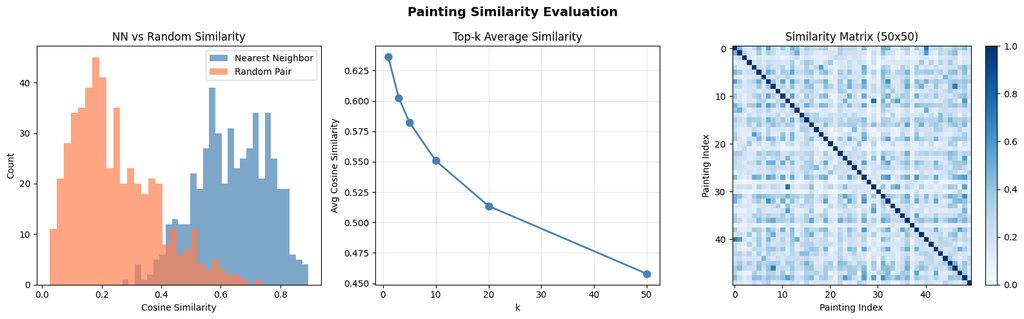

```
Metrics saved to /content/drive/MyDrive/Similarity_Results
{
  "num_images": 498,
  "embedding_dim": 2048,
  "nn_similarity_mean": 0.6362431645393372,
  "nn_similarity_median": 0.6354782581329346,
  "random_similarity_mean": 0.2445434646336848,
  "nn_random_ratio": 2.6017590185548447,
  "num_artist_groups": 2
}
```

```python
# ===== EVALUATION: Embedding-based Similarity Analysis =====
from collections import defaultdict

# First try artist-based evaluation
labels = [str(d.get('artist', 'unknown')) for d in downloaded]
artist_groups = defaultdict(set)
for i, label in enumerate(labels):
    if label.lower() not in ('unknown', 'nan', ''):
        artist_groups[label].add(i)

print(f"Artist groups with labels: {len(artist_groups)}")

# Compute similarity statistics (works even without labels)
print("\n" + "="*60)
print("  SIMILARITY ANALYSIS")
print("="*60)

# 1. Nearest-neighbor similarity distribution
nn_sims = []  # similarity to nearest neighbor
rand_sims = []  # similarity to random pairs
np.random.seed(42)

for i in range(len(embeddings)):
    sims = embeddings @ embeddings[i]
    sims[i] = -1  # exclude self
    nn_sims.append(np.max(sims))  # nearest neighbor similarity
    rand_idx = np.random.choice([j for j in range(len(embeddings)) if j != i])
    rand_sims.append(float(sims[rand_idx]))

nn_sims = np.array(nn_sims)
rand_sims = np.array(rand_sims)

print(f"\n  Nearest Neighbor Similarity:")
print(f"    Mean: {nn_sims.mean():.4f}")
print(f"    Median: {np.median(nn_sims):.4f}")
print(f"    Min: {nn_sims.min():.4f}")

print(f"\n  Random Pair Similarity:")
print(f"    Mean: {rand_sims.mean():.4f}")
print(f"    Median: {np.median(rand_sims):.4f}")

ratio = nn_sims.mean() / max(rand_sims.mean(), 1e-8)
print(f"\n  NN / Random Ratio: {ratio:.2f}x")
print(f"  → Nearest neighbors are {ratio:.1f}x more similar than random pairs")

# 2. Top-k average similarity
print(f"\n  Top-k Average Similarity:")
for k in [1, 3, 5, 10]:
    top_k_sims = []
    for i in range(len(embeddings)):
        sims = embeddings @ embeddings[i]
        sims[i] = -1
        top_k = np.sort(sims)[::-1][:k]
        top_k_sims.append(np.mean(top_k))
    print(f"    Top-{k:2d} avg similarity: {np.mean(top_k_sims):.4f}")

# 3. Artist-based evaluation if available
if len(artist_groups) > 0:
    k_values = [1, 3, 5, 10, 20]
    valid_queries = [i for i in range(len(labels))
                     if labels[i].lower() not in ('unknown','nan','')
                     and len(artist_groups.get(labels[i], set())) > 1]
    if valid_queries:
        print(f"\n  Artist-based Precision@k ({len(valid_queries)} queries):")
        for k in k_values:
            precs = []
            for q in valid_queries:
                relevant = artist_groups[labels[q]] - {q}
                sims = embeddings @ embeddings[q]
                sims[q] = -1
                top_k = np.argsort(sims)[::-1][:k]
                precs.append(sum(1 for idx in top_k if idx in relevant)/k)
            print(f"    Precision@{k}: {np.mean(precs)*100:.1f}%")

# 4. Plot
fig, axes = plt.subplots(1, 3, figsize=(16, 5))

# Histogram of NN vs Random similarity
axes[0].hist(nn_sims, bins=30, alpha=0.7, label='Nearest Neighbor', color='steelblue')
axes[0].hist(rand_sims, bins=30, alpha=0.7, label='Random Pair', color='coral')
axes[0].set_xlabel('Cosine Similarity')
axes[0].set_ylabel('Count')
axes[0].set_title('NN vs Random Similarity')
axes[0].legend()

# Top-k similarity curve
ks = [1, 3, 5, 10, 20, 50]
avg_topk = []
for k in ks:
    topk_vals = []
    for i in range(len(embeddings)):
        sims = embeddings @ embeddings[i]; sims[i] = -1
        topk_vals.append(np.mean(np.sort(sims)[::-1][:k]))
    avg_topk.append(np.mean(topk_vals))
axes[1].plot(ks, avg_topk, 'o-', color='steelblue', linewidth=2, markersize=8)
axes[1].set_xlabel('k')
axes[1].set_ylabel('Avg Cosine Similarity')
axes[1].set_title('Top-k Average Similarity')
axes[1].grid(True, alpha=0.3)

# Similarity heatmap (sample)
sample = min(50, len(embeddings))
sim_matrix = embeddings[:sample] @ embeddings[:sample].T
im = axes[2].imshow(sim_matrix, cmap='Blues', vmin=0, vmax=1)
axes[2].set_title(f'Similarity Matrix ({sample}x{sample})')
axes[2].set_xlabel('Painting Index')
axes[2].set_ylabel('Painting Index')
plt.colorbar(im, ax=axes[2], fraction=0.046)

plt.suptitle('Painting Similarity Evaluation', fontsize=14, fontweight='bold')
plt.tight_layout()
plt.savefig(os.path.join(RESULTS_DIR, 'evaluation_metrics.png'), dpi=150)
plt.show()

# Save metrics
metrics = {
    'num_images': len(embeddings), 'embedding_dim': int(embeddings.shape[1]),
    'nn_similarity_mean': float(nn_sims.mean()),
    'nn_similarity_median': float(np.median(nn_sims)),
    'random_similarity_mean': float(rand_sims.mean()),
    'nn_random_ratio': float(ratio),
    'num_artist_groups': len(artist_groups),
}
with open(os.path.join(RESULTS_DIR, 'similarity_metrics.json'), 'w') as f:
    json.dump(metrics, f, indent=2)
print(f'\nMetrics saved to {RESULTS_DIR}')
print(json.dumps(metrics, indent=2))
```